# Cv

Isha Savaliya | a. Load dataset (`photos.json`) and verify image paths. | Load the dataset and check if image paths are valid. | | b. Preprocess images (resize to `32x32`, flatten the images). | Resize images to `(32x32)` and flatten them for the kNN model. | | c. Encode labels with `LabelEncoder`. | Convert the text labels into numeric format using `LabelEncoder`. | | d. Extract features (`X`) and labels (`y`). | Store preprocessed images in `X` and encoded labels in `y`. |

Vandit Kalathiya | a. Split data into training (80%) and testing (20%) using `train_test_split`. | Split the dataset into 80% for training and 20% for testing. | | b. Hyperparameter tuning using **GridSearchCV** or **RandomizedSearchCV**. | Tune hyperparameters like `n_neighbors`, `metric`, and `weights` using grid search or randomized search. | | c. Train the kNN model using the best hyperparameters from tuning. | Train the kNN model with the selected hyperparameters. | | d. Evaluate the model on the test data: Accuracy, AUC, and ROC curves. | Evaluate the model using accuracy, AUC, and ROC curve metrics. |

```python
import os
import json
import numpy as np
import pandas as pd
import matplotlib.pyplot as plt
import seaborn as sns

from PIL import Image

# scikit-learn for preprocessing, evaluation and kNN
from sklearn.model_selection import train_test_split, GridSearchCV
from sklearn.preprocessing import LabelEncoder
from sklearn.metrics import confusion_matrix, classification_report, roc_auc_score
from sklearn.neighbors import KNeighborsClassifier
from sklearn.preprocessing import label_binarize

# TensorFlow / Keras for the neural networks
import tensorflow as tf
from tensorflow.keras.models import Sequential
from tensorflow.keras.layers import Dense, Flatten, Conv2D, MaxPooling2D, Dropout, BatchNormalization
from tensorflow.keras.utils import to_categorical
from tensorflow.keras.callbacks import EarlyStopping

# For reproducibility
np.random.seed(42)
tf.random.set_seed(42)
```

```python
import pandas as pd
import numpy as np
import os
from PIL import Image

# Define paths
json_path = r"D:\Loyalist college\computer vision\Yelp-Photos\Yelp Photos\yelp_photos\photos.json"
image_dir = r"D:\Loyalist college\computer vision\Yelp-Photos\Yelp Photos\yelp_photos\photos"

# Load the JSON file
df = pd.read_json(json_path, lines=True)

# Select only 10,000 random images
df = df.sample(n=10000, random_state=42)

# Create full image paths using the correct folder
df['image_path'] = df['photo_id'].apply(lambda x: os.path.join(image_dir, f"{x}.jpg"))

# Check if files exist
df['exists'] = df['image_path'].apply(os.path.exists)

# Show missing files
missing_files = df[~df['exists']]
if not missing_files.empty:
    print("\n Warning: Some image files are missing! Here are the first 5 missing files:")
    display(missing_files[['photo_id', 'image_path']].head())
else:
    print("\n All image paths are valid!")

df.drop(columns=['exists'], inplace=True)

# Define preprocessing function
IMG_SIZE = (32, 32)

def preprocess_image(image_path):
    """Loads an image, converts to RGB, resizes to (32x32), and flattens it."""
    try:
        img = Image.open(image_path).convert('RGB')  # Ensure RGB mode
        img = img.resize(IMG_SIZE)  # Resize
        return np.array(img).flatten().astype(np.float16)  # Convert to float16 to save memory
    except Exception as e:
        print(f" Error processing image {image_path}: {e}")
        return None  # Skip failed images

df['image_array'] = df['image_path'].apply(preprocess_image)

# Drop rows where images could not be processed
df.dropna(subset=['image_array'], inplace=True)

# Print results
print("\n Preprocessing completed successfully!")
print(f"Total valid images processed: {len(df)}")

# Display first 5 processed images (flattened arrays)
df[['photo_id', 'image_array']].head()
```

```
 All image paths are valid!
 Error processing image D:\Loyalist college\computer vision\Yelp-Photos\Yelp Photos\yelp_photos\photos\1MOGQBWogR8oJr1WgERi9g.jpg: cannot identify image file 'D:\\Loyalist college\\computer vision\\Yelp-Photos\\Yelp Photos\\yelp_photos\\photos\\1MOGQBWogR8oJr1WgERi9g.jpg'
 Error processing image D:\Loyalist college\computer vision\Yelp-Photos\Yelp Photos\yelp_photos\photos\pW1IPuTdLIUB61goirbXaA.jpg: cannot identify image file 'D:\\Loyalist college\\computer vision\\Yelp-Photos\\Yelp Photos\\yelp_photos\\photos\\pW1IPuTdLIUB61goirbXaA.jpg'

 Preprocessing completed successfully!
Total valid images processed: 9998
```

|  | photo_id | image_array |
| --- | --- | --- |
| 32568 | k_PSngRS22mSA1MypwrjPg | [154.0, 121.0, 86.0, 173.0, 140.0, 101.0, 180.... |
| 174911 | D_94KivwVgitkzFIgE_KcQ | [218.0, 223.0, 226.0, 222.0, 226.0, 228.0, 220... |
| 132444 | Hf39P7_G_eRCqfVwvMDV6g | [122.0, 112.0, 100.0, 124.0, 114.0, 102.0, 116... |
| 46744 | agxl4sABeRXwjLL506KMrQ | [159.0, 152.0, 134.0, 160.0, 153.0, 134.0, 161... |
| 85073 | 7cZ0MREN2TwAAX4nnirQlA | [8.0, 4.0, 4.0, 9.0, 5.0, 4.0, 9.0, 5.0, 4.0, ... |

```python
from sklearn.preprocessing import LabelEncoder

# Check if the 'label' column exists in the dataset
if 'label' not in df.columns:
    raise ValueError("The dataset does not contain a 'label' column. Please check the dataset.")

# Encode labels
label_encoder = LabelEncoder()
df['encoded_label'] = label_encoder.fit_transform(df['label'])  # Convert text labels to numerical labels

# Extract feature matrix (X) and labels (y)
X = np.stack(df['image_array'].values)
y = df['encoded_label'].values

print(f" Labels encoded successfully!")
print(f"Unique encoded labels: {np.unique(y)}")
print(f"X shape: {X.shape}, y shape: {y.shape}")
```

```
 Labels encoded successfully!
Unique encoded labels: [0 1 2 3 4]
X shape: (9998, 3072), y shape: (9998,)
```

```python
from sklearn.model_selection import train_test_split

# Split the dataset into training (80%) and testing (20%)
X_train, X_test, y_train, y_test = train_test_split(
    X, y, test_size=0.2, random_state=42, stratify=y
)

print(f" Train-Test Split Completed!")
print(f"Training set: X_train shape: {X_train.shape}, y_train shape: {y_train.shape}")
print(f"Testing set: X_test shape: {X_test.shape}, y_test shape: {y_test.shape}")
```

```
 Train-Test Split Completed!
Training set: X_train shape: (7998, 3072), y_train shape: (7998,)
Testing set: X_test shape: (2000, 3072), y_test shape: (2000,)
```

```python
from sklearn.neighbors import KNeighborsClassifier
from sklearn.model_selection import GridSearchCV

knn = KNeighborsClassifier()

param_grid = {'n_neighbors': [3, 5, 7, 9, 11]}

# Perform grid search with cross-validation
grid_search = GridSearchCV(knn, param_grid, cv=3, scoring='accuracy', n_jobs=-1)
grid_search.fit(X_train, y_train)

best_k = grid_search.best_params_['n_neighbors']
print(f" Best k found: {best_k}")

# Train the final model with the best k
knn_best = KNeighborsClassifier(n_neighbors=best_k)
knn_best.fit(X_train, y_train)

print(" kNN Model Trained Successfully!")
```

```
 Best k found: 11
 kNN Model Trained Successfully!
```

```
 Training Accuracy: 0.7443
 Testing Accuracy: 0.7075

Classification Report:
               precision    recall  f1-score   support

           0       0.58      0.21      0.31       157
           1       0.78      0.85      0.81      1090
           2       0.60      0.70      0.65       556
           3       0.00      0.00      0.00        16
           4       0.60      0.38      0.46       181

    accuracy                           0.71      2000
   macro avg       0.51      0.43      0.45      2000
weighted avg       0.69      0.71      0.69      2000
```

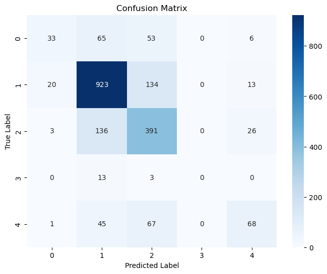

```python
from sklearn.metrics import accuracy_score, classification_report, confusion_matrix
import seaborn as sns
import matplotlib.pyplot as plt

y_pred = knn_best.predict(X_test)

# Calculate accuracy
train_acc = knn_best.score(X_train, y_train)
test_acc = accuracy_score(y_test, y_pred)

print(f" Training Accuracy: {train_acc:.4f}")
print(f" Testing Accuracy: {test_acc:.4f}")

# Print classification report
print("\nClassification Report:\n", classification_report(y_test, y_pred))

# Confusion Matrix
plt.figure(figsize=(8, 6))
conf_matrix = confusion_matrix(y_test, y_pred)
sns.heatmap(conf_matrix, annot=True, fmt='d', cmap='Blues')

plt.xlabel("Predicted Label")
plt.ylabel("True Label")
plt.title("Confusion Matrix")
plt.show()
```

```python
from sklearn.metrics import roc_auc_score
from sklearn.preprocessing import label_binarize

# Binarize the labels (necessary for multi-class AUC calculation)
y_test_bin = label_binarize(y_test, classes=np.unique(y))  # Binary encoding for multi-class
y_pred_bin = knn_best.predict_proba(X_test)  # Get predicted probabilities for each class

# Calculate the AUC score for each class
auc_scores = roc_auc_score(y_test_bin, y_pred_bin, average=None, multi_class='ovr')

# Display AUC for each class
for i, auc in enumerate(auc_scores):
    print(f"Class {i}: AUC = {auc:.4f}")

# Calculate and print the macro-average AUC
macro_auc = roc_auc_score(y_test_bin, y_pred_bin, average='macro', multi_class='ovr')
print(f" Macro-average AUC: {macro_auc:.4f}")
```

```
Class 0: AUC = 0.6976
Class 1: AUC = 0.8603
Class 2: AUC = 0.8359
Class 3: AUC = 0.6974
Class 4: AUC = 0.8272
 Macro-average AUC: 0.7837
```

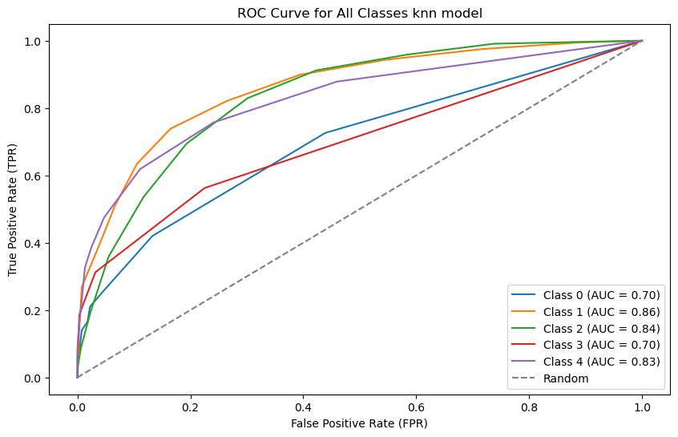

```python
from sklearn.metrics import roc_curve

# Binarize the labels (necessary for multi-class ROC curve)
y_test_bin = label_binarize(y_test, classes=np.unique(y))  # Binary encoding for multi-class
y_pred_bin = knn_best.predict_proba(X_test)  # Get predicted probabilities for each class

# Create the plot
plt.figure(figsize=(10, 6))

# Loop through each class to plot the ROC curve
for i in range(y_test_bin.shape[1]):
    # Get ROC curve
    fpr, tpr, _ = roc_curve(y_test_bin[:, i], y_pred_bin[:, i])

    # Plot the ROC curve for each class
    plt.plot(fpr, tpr, label=f'Class {i} (AUC = {auc_scores[i]:.2f})')

# Plot the diagonal line (no discrimination)
plt.plot([0, 1], [0, 1], linestyle='--', color='gray', label='Random')

# Adding labels and title
plt.xlabel('False Positive Rate (FPR)')
plt.ylabel('True Positive Rate (TPR)')
plt.title('ROC Curve for All Classes knn model')

plt.legend(loc='lower right')

# Display the plot
plt.show()
```

TUNNING

```python
from sklearn.neighbors import KNeighborsClassifier
from sklearn.model_selection import train_test_split

# Manually select hyperparameters
k_values = [3, 5, 7]
metrics = ['euclidean', 'manhattan']
weights = ['uniform', 'distance']

# Create a dictionary to store results
results = {}

# Train and evaluate the models with different configurations
for k in k_values:
    for metric in metrics:
        for weight in weights:
            print(f"Training kNN with k={k}, metric={metric}, weight={weight}")
            knn = KNeighborsClassifier(n_neighbors=k, metric=metric, weights=weight)
            knn.fit(X_train, y_train)

            # Calculate accuracy
            train_acc = knn.score(X_train, y_train)
            test_acc = knn.score(X_test, y_test)

            # Store the results
            results[(k, metric, weight)] = {
                'train_accuracy': train_acc,
                'test_accuracy': test_acc
            }

# Display the results
for config, scores in results.items():
    print(f"\nConfig: {config}")
    print(f"Train Accuracy: {scores['train_accuracy']:.4f}, Test Accuracy: {scores['test_accuracy']:.4f}")
```

```
Training kNN with k=3, metric=euclidean, weight=uniform
Training kNN with k=3, metric=euclidean, weight=distance
Training kNN with k=3, metric=manhattan, weight=uniform
Training kNN with k=3, metric=manhattan, weight=distance
Training kNN with k=5, metric=euclidean, weight=uniform
Training kNN with k=5, metric=euclidean, weight=distance
Training kNN with k=5, metric=manhattan, weight=uniform
Training kNN with k=5, metric=manhattan, weight=distance
Training kNN with k=7, metric=euclidean, weight=uniform
Training kNN with k=7, metric=euclidean, weight=distance
Training kNN with k=7, metric=manhattan, weight=uniform
Training kNN with k=7, metric=manhattan, weight=distance

Config: (3, 'euclidean', 'uniform')
Train Accuracy: 0.7994, Test Accuracy: 0.6170

Config: (3, 'euclidean', 'distance')
Train Accuracy: 1.0000, Test Accuracy: 0.6325

Config: (3, 'manhattan', 'uniform')
Train Accuracy: 0.8013, Test Accuracy: 0.6300

Config: (3, 'manhattan', 'distance')
Train Accuracy: 1.0000, Test Accuracy: 0.6495

Config: (5, 'euclidean', 'uniform')
Train Accuracy: 0.7698, Test Accuracy: 0.6695

Config: (5, 'euclidean', 'distance')
Train Accuracy: 1.0000, Test Accuracy: 0.6665

Config: (5, 'manhattan', 'uniform')
Train Accuracy: 0.7772, Test Accuracy: 0.6870

Config: (5, 'manhattan', 'distance')
Train Accuracy: 1.0000, Test Accuracy: 0.6830

Config: (7, 'euclidean', 'uniform')
Train Accuracy: 0.7536, Test Accuracy: 0.6870

Config: (7, 'euclidean', 'distance')
Train Accuracy: 1.0000, Test Accuracy: 0.6835

Config: (7, 'manhattan', 'uniform')
Train Accuracy: 0.7657, Test Accuracy: 0.6890

Config: (7, 'manhattan', 'distance')
Train Accuracy: 1.0000, Test Accuracy: 0.6875
```

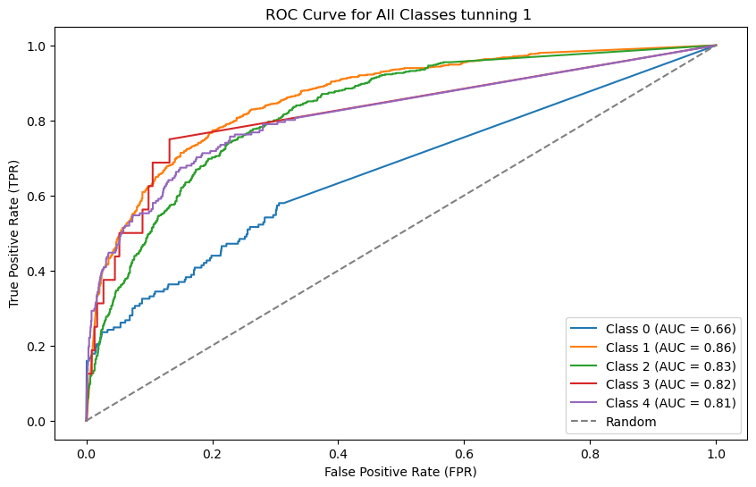

```
 Macro-average AUC: 0.7982
```

```python
from sklearn.metrics import roc_curve, roc_auc_score
import matplotlib.pyplot as plt
from sklearn.preprocessing import label_binarize

# Binarize the labels (necessary for multi-class ROC)
y_test_bin = label_binarize(y_test, classes=np.unique(y))  # Binary encoding for multi-class
y_pred_bin = knn.predict_proba(X_test)  # Get predicted probabilities for each class

# Create the plot
plt.figure(figsize=(10, 6))

# Loop through each class to plot the ROC curve
for i in range(y_test_bin.shape[1]):
    # Get ROC curve
    fpr, tpr, _ = roc_curve(y_test_bin[:, i], y_pred_bin[:, i])

    # Plot the ROC curve for each class
    plt.plot(fpr, tpr, label=f'Class {i} (AUC = {roc_auc_score(y_test_bin[:, i], y_pred_bin[:, i]):.2f})')

# Plot the diagonal line (no discrimination)
plt.plot([0, 1], [0, 1], linestyle='--', color='gray', label='Random')

# Adding labels and title
plt.xlabel('False Positive Rate (FPR)')
plt.ylabel('True Positive Rate (TPR)')
plt.title('ROC Curve for All Classes tunning 1 ')

plt.legend(loc='lower right')

# Display the plot
plt.show()

# Calculate the macro-average AUC
macro_auc = roc_auc_score(y_test_bin, y_pred_bin, average='macro', multi_class='ovr')
print(f" Macro-average AUC: {macro_auc:.4f}")
```

```python
!jupyter nbconvert --to html Cv.ipynb
```

```
[NbConvertApp] Converting notebook Cv.ipynb to html
[NbConvertApp] WARNING | Alternative text is missing on 3 image(s).
[NbConvertApp] Writing 576295 bytes to Cv.html
```